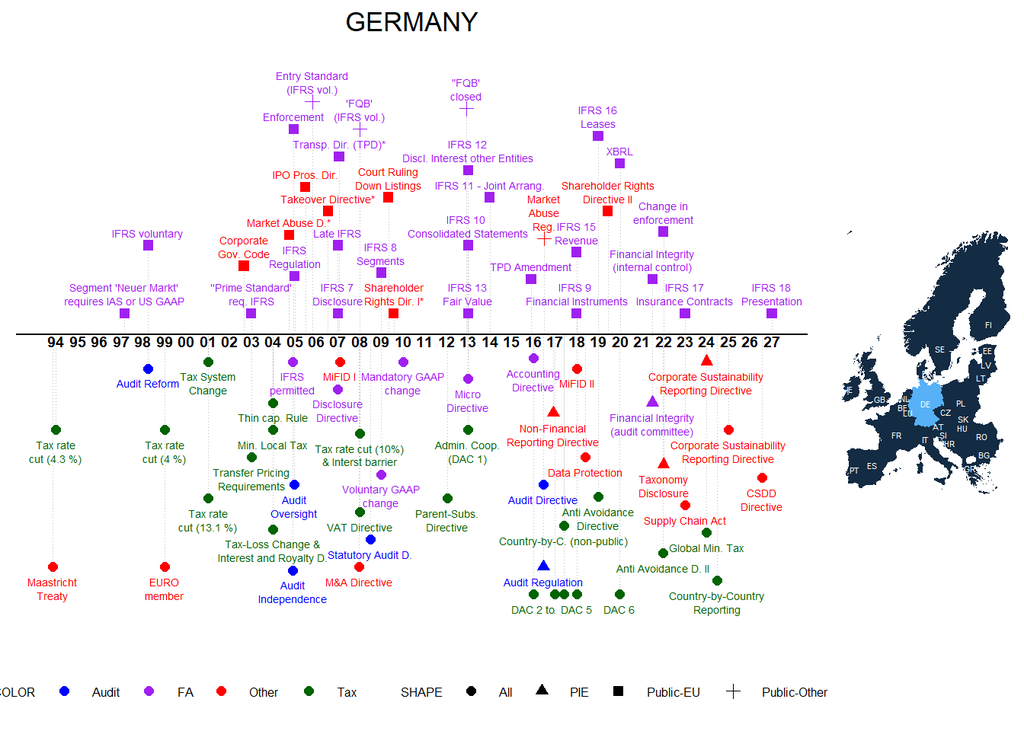

Notes: The graph depicts major regulatory changes that we identified via an extensive literature search, an online survey of mentioned authors, and other sources. Please note that the graph does not include all possible regulatory changes, e.g. minor revisions to local GAAP or tax rate changes below 3% are not included. The dates of EU Directives are based on the official transposition deadlines unless denoted with a *, in which case we included the entry-to-force date as identified in the literature. For more information, please go to [Labro and Pierk (2023)](http://www.eu-regulations.com/Labro_Pierk_2023.pdf). We kindly ask that you cite the paper if you use the information on this website in your research project. Do you have comments or see anything missing? Please email us!

## Regulations, Publications, Further Graphs

The tab ‘Regulations’ includes links to the regulations, gives short descriptions, and provides selective papers for further reading. If the regulation is a national transposition of an EU Directive, the link to the Directive is given. The tab ‘Number of Regulations’ shows graphically the number of regulations 8 years around the respective year (-4,-3,-2,-1,0,+1,+2,+3). The tab ‘Number of Categories” shows graphically the number of different categories 8 years around the respective year (-4,-3,-2,-1,0,+1,+2,+3). The tab ’Publications’ shows all publications that include the countries’ names and variations thereof in the title, abstract, or keywords. Similarly, the tab ‘SSRN’ shows papers of the SSRN Accouning Research Network that include the countries’ names and variations.

### Regulations

[output not shown]

[output cut: 72 more lines]

### Number of Regulations

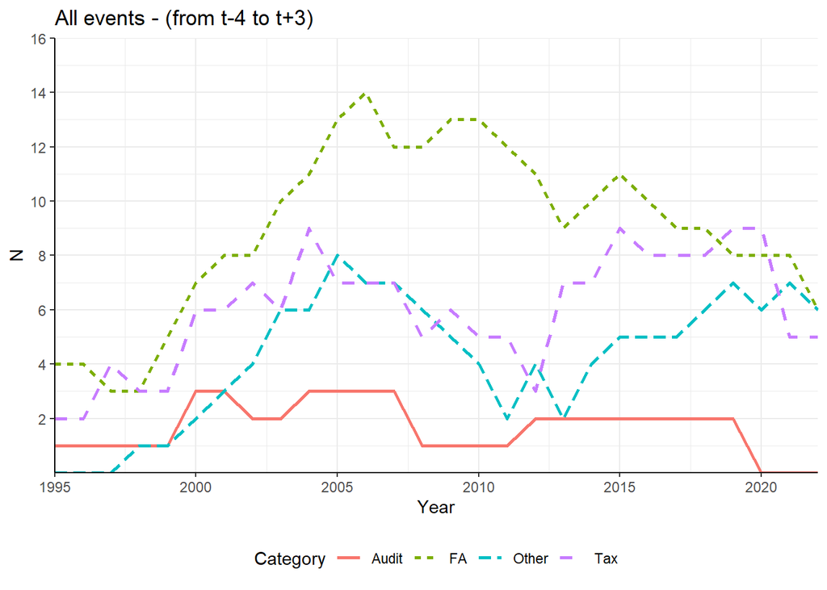

### Number of Categories

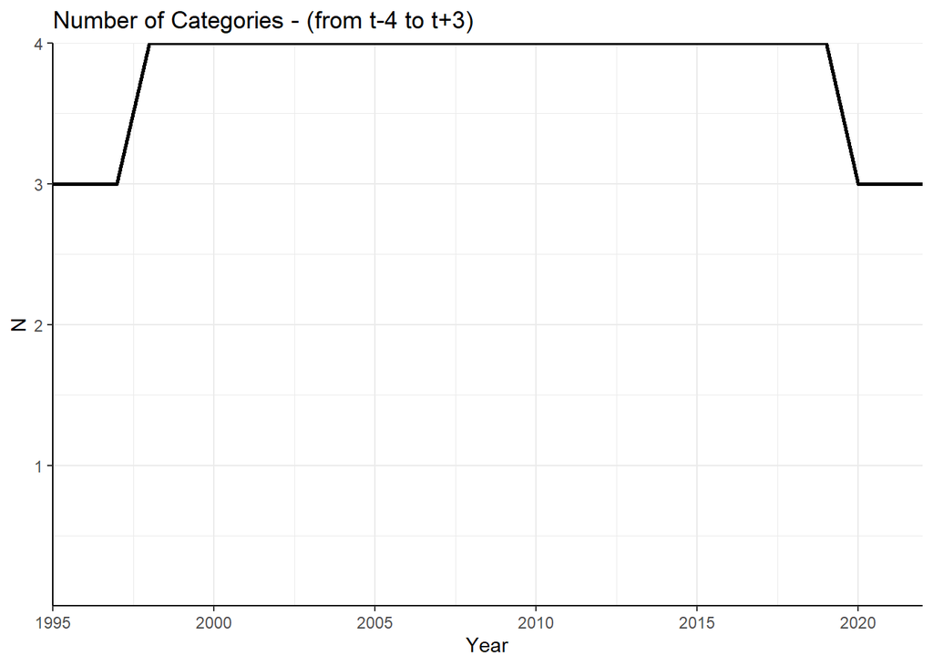

### Publications

|  | authors | title | year | journal |
| --- | --- | --- | --- | --- |
| 1 | Aghamolla C., Thakor R.T. | do mandatory disclosure requirements for private firms increase the propensity of going public? | 2021 | Journal of Accounting Research |
| 2 | Bernard D., Kaya D., Wertz J. | entry and capital structure mimicking in concentrated markets: the role of incumbents’ financial disclosures | 2021 | Journal of Accounting and Economics |
| 3 | Bonsón E., Lavorato D., Lamboglia R., Mancini D. | artificial intelligence activities and ethical approaches in leading listed companies in the european union | 2021 | International Journal of Accounting Information Systems |
| 4 | Ding R., Liu M., Wang T., Wu Z. | the impact of climate risk on earnings management: international evidence | 2021 | Journal of Accounting and Public Policy |
| 5 | Downar B., Ernstberger J., Koch C. | who makes partner in big 4 audit firms? – evidence from germany | 2021 | Accounting, Organizations and Society |
| 6 | Elemes A., Blaylock B., Spence C. | tax-motivated profit shifting in big 4 networks: evidence from europe | 2021 | Accounting, Organizations and Society |
| 7 | Glaeser S., Omartian J.D. | public firm presence, financial reporting, and the decline of u.s. manufacturing | 2021 | Journal of Accounting Research |
| 8 | Gleason C.A., Kieback S., Thomsen M., Watrin C. | monitoring or payroll maximization? what happens when workers enter the boardroom? | 2021 | Review of Accounting Studies |
| 9 | Guan Y., Wang Z., Wong M.H.F., Xin X. | language and management forecasts around the world* | 2021 | Contemporary Accounting Research |
| 10 | Hahnenstein L., Köchling G., Posch P.N. | do firms hedge in order to avoid financial distress costs? new empirical evidence using bank data | 2021 | Journal of Business Finance and Accounting |

[output cut: 213 more lines]

### SSRN

|  | authors | title | Posted | Revised |
| --- | --- | --- | --- | --- |
| 1 | Matthias Breuer, Christian Leuz and Steven Vanhaverbeke | reporting regulation and corporate innovation | 2021-12-22 |  |
| 2 | Andreas Lichter, Max Löffler, Ingo E. Isphording, Thu-Van Nguyen, Felix Poege, Sebastian Siegloch and Sebastian Siegloch | profit taxation, r&d spending, and innovation | 2021-12-15 |  |
| 3 | Dirk Otto Beerbaum | the future of audit after the wirecard accounting scandal – proposal for a change in the payment model | 2021-11-18 |  |
| 4 | Marius Gros, Marius Gros and Anika Hanke | if humans fail, machines take action: assessment of accounting error detection using machine learning | 2021-11-18 |  |
| 5 | Ingo E. Isphording, Andreas Lichter, Max Löffler, Thu-Van Nguyen, Felix Poege and Sebastian Siegloch | profit taxation, r&d spending, and innovation | 2021-11-15 |  |
| 6 | Chen Lin, Thomas Schmid and Huai Zhang | do employees prefer conservative accounting? | 2021-11-14 | 2021-11-17 |
| 7 | Rüdiger Bachmann, Kai Carstensen, Stefan Lautenbacher and Martin Schneider | uncertainty and change: survey evidence of firms' subjective beliefs | 2021-11-12 |  |
| 8 | Rüdiger Bachmann, Kai Carstensen, Stefan Lautenbacher and Martin Schneider | uncertainty and change: survey evidence of firms' subjective beliefs | 2021-11-09 |  |
| 9 | Rüdiger Bachmann, Benjamin Born, Olga Goldfayn-Frank, Georgi Kocharkov, Georgi Kocharkov, Ralph Luetticke and Michael Weber | a temporary vat cut as unconventional fiscal policy | 2021-10-26 | 2021-10-28 |
| 10 | Vanessa Behrmann, Lars Hornuf, Jochen Zimmermann and Jochen Zimmermann | disclosure deregulation of quarterly reporting | 2021-10-18 |  |

[output cut: 67 more lines]